# How does a student’s background impact their performance on end of year exam?

Cecilia Fu

26/05/2020

In this project, we are interested in the impact of a student’s background on their performance in school, we will use their test scores as a way of evaluation on their performance in school and a set of variables (listed below) as a student’s background. The file school.csv contains data on 992 Grade 8 students in 58 primary schools in the Netherlands, data is adapted from Snijders and Boskers’ Multilevel Analysis, Second Edition (Sage, 2012).

# Examination of Data

```r
glimpse(school_data)
```

```
## Observations: 992
## Variables: 8
## $ X               <int> 1, 2, 3, 4, 5, 6, 7, 8, 9, 10, 11, 12, 13, 14, 15, 16…
## $ school          <int> 1, 1, 1, 1, 1, 1, 1, 1, 1, 1, 1, 1, 1, 1, 1, 1, 1, 1,…
## $ ses             <dbl> -4.73, -17.73, -12.73, -4.73, -17.73, -17.73, -4.73, …
## $ test            <int> 46, 45, 33, 46, 20, 30, 30, 57, 36, 36, 29, 40, 41, 4…
## $ iq              <dbl> 3.13, 2.63, -2.37, -0.87, -3.87, -2.37, -2.37, 1.13, …
## $ sex             <int> 0, 0, 0, 0, 0, 0, 0, 0, 0, 0, 1, 0, 0, 0, 0, 0, 1, 1,…
## $ minority_status <int> 0, 1, 0, 0, 0, 1, 1, 0, 1, 1, 1, 0, 1, 1, 1, 0, 0, 1,…
## $ denomination    <int> 1, 1, 1, 1, 1, 1, 1, 1, 1, 1, 1, 1, 1, 1, 1, 1, 1, 1,…
```

From glancing at the variables of the data, we can see that each student is within a school which makes the students that are in the same school not independent of eachother. This is a violation of our assumption for fitting a linear model, thus we need to use linear mixed model instead.

Let’s take a look at the scatter plot of all the variables against our criterion variable to see the overall affect of these variables on the end of year test score.

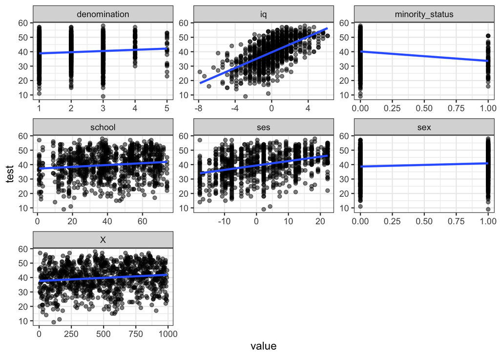

```r
school_data %>%
  gather(-test, key = "var", value = "value") %>%
  ggplot(aes(x = value, y = test)) +
    geom_point(alpha=0.5) +
    geom_smooth(method = "lm", se=FALSE) +
    theme_classic() +
    facet_wrap(~ var, scales = "free") +
    theme_bw()
```

# Fitting a Model

As I have explained before, fitting a linear model is not reasonable since this set of data violates our assumption for a linear model. Instead, a suitable model would be a linear mixed model with a random intercept for school, which accounts for the dependence between students of the same school.

```r
#adding new variable mean_ses, mean_iq for each school to the dataset
school2<- school_data %>% group_by(school) %>% mutate(mean_ses = mean(ses), mean_iq = mean(iq))

school_lmm <- lme4::lmer(test~iq+sex+ses+minority_status+mean_ses+mean_iq+(1|school), data = school2)

summary(school_lmm)
```

```
## Linear mixed model fit by REML ['lmerMod']
## Formula: test ~ iq + sex + ses + minority_status + mean_ses + mean_iq +
##     (1 | school)
##    Data: school2
##
## REML criterion at convergence: 6518.1
##
## Scaled residuals:
##     Min      1Q  Median      3Q     Max
## -3.9926 -0.6304  0.0757  0.6945  2.6361
##
## Random effects:
##  Groups   Name        Variance Std.Dev.
##  school   (Intercept)  8.177   2.859
##  Residual             38.240   6.184
## Number of obs: 992, groups:  school, 58
##
## Fixed effects:
##                 Estimate Std. Error t value
## (Intercept)     38.37951    0.48384  79.323
## iq               2.27784    0.10881  20.935
## sex              2.29199    0.40260   5.693
## ses              0.19283    0.02396   8.047
## minority_status -0.65259    0.96943  -0.673
## mean_ses        -0.20131    0.08000  -2.517
## mean_iq          1.62512    0.52017   3.124
##
## Correlation of Fixed Effects:
##             (Intr) iq     sex    ses    mnrty_ men_ss
## iq          -0.035
## sex         -0.408  0.045
## ses          0.013 -0.284 -0.048
## minrty_stts -0.129  0.131  0.001  0.053
## mean_ses    -0.140  0.092  0.003 -0.296  0.039
## mean_iq      0.089 -0.199 -0.007  0.064  0.052 -0.494
```

```r
confint(school_lmm)
```

```
## Computing profile confidence intervals ...
```

```
##                      2.5 %      97.5 %
## .sig01           2.1818595  3.51821014
## .sigma           5.9011373  6.46042873
## (Intercept)     37.4412106 39.31755070
## iq               2.0649432  2.49094360
## sex              1.5044771  3.08014874
## ses              0.1459275  0.23975452
## minority_status -2.5423935  1.24925972
## mean_ses        -0.3564217 -0.04606047
## mean_iq          0.6166461  2.63522563
```

Intercept interpretation: male students with 0 for the IQ (0 standard deviation from the mean IQ of all students) and SES at a school with 0 for the mean SES and mean IQ at an average school, with 95% confidence interval we can confirm their average end of year test score is between 37.4 and 39.31 marks.

Variable interpretation:

The average marks for female students are 1.5 to 3.08 higher than those of male students.

For each one unit increase in IQ, the test mark increase by between 2.06 and 2.49.

Personally having a higher SES are associated with a higher test mark, but being in a school with higher SES slightly decreases the average test mark (decrease by between 0.36 and 0.046)

Minority_status is insignificant since the confidence interval includes 0, which means that being a minority could have 0 impact on the end of year test score.

For the random effect, we see 8.2 variability amongst the intercept for school. A school that has a one standard deviation higher intercept than another school has about 2.9 marks higher average test score.

# Is it reasonable to include a random effect for different schools?

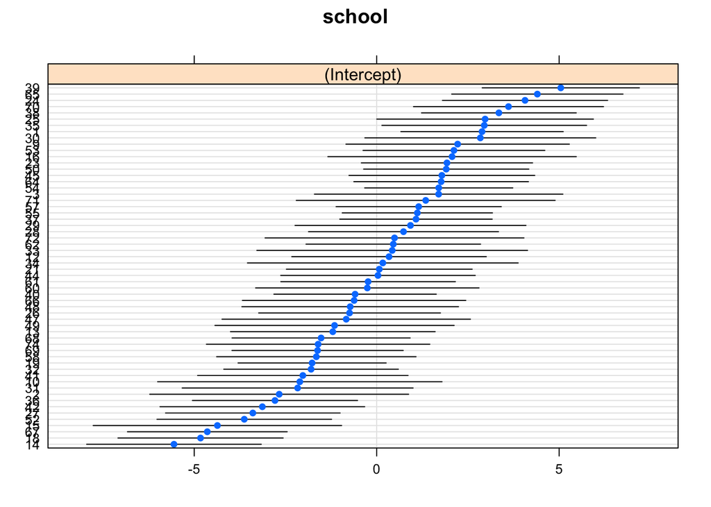

```r
lattice::dotplot(lme4::ranef(school_lmm))
```

Yes, it seems reasonable to include these random effects since many schools have significantly different estimated random effects as the confidence intervals don’t overlap.

# What have we learned? Does a student’s background have anything to do with their test scores?

From analyzing the data above and fitting a model, we learned that as a female student, higher IQ higher personal SES score and being in a school with higher mean IQ increases the test score, and being in a school with higher ses will decrease the average test score. Therefore, we can reasonably conclude that a student’s background does impact their end of year test scores.